# Making Smart Thermostats Smarter

## Using Classification for Inference and Prediction

Ecobee provides donated customer datasets on its website, allowing for analytics on large smart thermostat datasets. This dataset contains records for thermostat readings for every five minutes for one year, starting January first. Continuous predictor fields include outoor temperature and humidity, indoor average temperature and humidity, the cool and heat setpoints, and the categorical fields of Event and Schedule. The response variable is Override, indicating if the user has changed the set point temperature from the what the smart thermostat has selected.

The smart thermostat sets the indoor temperature based on preprogramming. Building statistical models to predict whether the user will override the set temperature will create pathways to improve smart thermostat performance.

*NOTE*: There is no indication of the geolocation of the home where the data was collected, so outdoor environmental factors are considered out of the context of local weather, and notes are given where assumptions are made based on the location of the home during the exploratory and visualization portions of the project.

## Project Notes

This notebook is adapted from an assignment for the course Experiential Artificial Intelligence 6000, "Fundamentals of Artificial Intelligence", through the Roux Institute at Northeastern University. The assignment focused on classification model familiarization. This notebook shifts from that focus to inference of customer behavior and possible steps taken to improve thermostat performance.

### Use of AI

Northeastern University provides all students subscription access to Claude.ai. For this project, Claude was used for quereying, constructing complicated plots where needed, and used in discussions about various model hyperparameters and performance measures.

### Loading Packages and Dataset

```python
# Base packages
import pandas as pd
import numpy as np
import matplotlib.pyplot as plt
import seaborn as sns
import math
import datetime
```

```python
# load data set
df = pd.read_parquet("df.parquet")

# Check shape
df.shape
```

```
(105120, 9)
```

```python
# First five rows
df.head()
```

| time | Event | Schedule | Indoor_AverageTemperature | Indoor_Humidity | Outdoor_Temperature | Outdoor_Humidity | Indoor_CoolSetpoint | Indoor_HeatSetpoint | Override |
| --- | --- | --- | --- | --- | --- | --- | --- | --- | --- |
| 2017-01-01 00:00:00 |  | Sleep | 70.0 | 62.0 | 63.0 | 94.0 | 71.0 | 68.0 | No Override |
| 2017-01-01 00:05:00 |  | Sleep | 70.0 | 62.0 | 63.0 | 94.0 | 71.0 | 68.0 | No Override |
| 2017-01-01 00:10:00 |  | Sleep | 70.0 | 62.0 | 63.0 | 94.0 | 71.0 | 68.0 | No Override |
| 2017-01-01 00:15:00 |  | Sleep | 70.0 | 62.0 | 63.0 | 94.0 | 71.0 | 68.0 | No Override |
| 2017-01-01 00:20:00 |  | Sleep | 70.0 | 62.0 | 63.0 | 94.0 | 71.0 | 68.0 | No Override |

```python
X = df.drop("Override", axis=1)
y = df["Override"]
```

### Training/Testing Split

The data will be split randomly, using 90% of the original dataset for training and 10% for model testing and performance validation. While the dataset is indexed using a date-time stamp, it will not be strictly treated as a time series. To do so would require further data -- the following year -- to recognize cyclical patterns, and to test model accuracy on a similar timeframe. Since the data contains exactly one year of records, a predictive model trained on data from January to August would likely perform poorly when tested against hold-out data from September to December. Using 90% of the 105,120 records will provide enough data to allow for accurate inference of cyclical or time-specific patterns that are present in the dataset as a whole.

The training and test set will be stratified so that there is a balanced representation of the response in both sets, avoiding potential issues where the positive case of the response is randomly over-represented in one set and rarely present in another.

```python
# import train_teset_split from sk learn
from sklearn.model_selection import train_test_split

X_train, X_test, y_train, y_test = train_test_split(
    X,y,
    test_size = 0.1,
    random_state = 4,
    stratify = y # We'll use the stratify to make sure there are equal number of 1/0 of the response in both sets
)
```

## Exploratory Data Analysis

```python
# The original data set is indexed by time-stamp. The original index will be converted to a column
# Create date_time field
X_train.reset_index(inplace = True,
              names = 'date_time')
```

```python
# reindex the response
y_train.reset_index(drop=True, inplace=True)
```

```python
#encode the response
from sklearn.preprocessing import LabelEncoder

le = LabelEncoder()

y_train_encoded = le.fit_transform(y_train)
y_test_encoded = le.transform(y_test)

print("Classes:", le.classes_)
print("No Override =", le.transform(["No Override"])[0])
print("Override =", le.transform(["Override"])[0])
```

```
Classes: ['No Override' 'Override']
No Override = 0
Override = 1
```

#### How often is Override Engaged?

Looking at the frequency of overrides in the data set will give us a base-line naive accuracy: if any model was to predict for "No Override" for all observations, how accurate would it be?

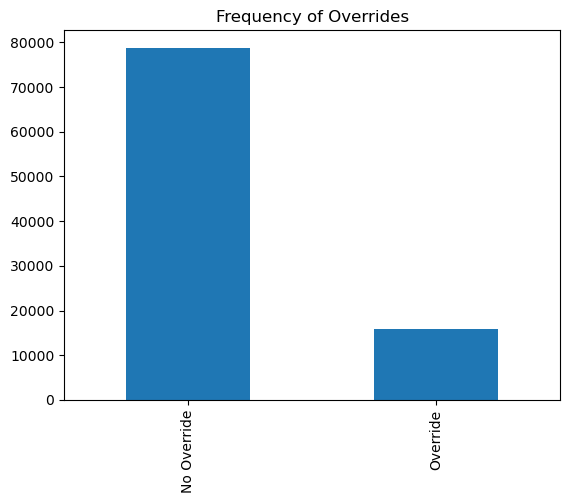

```python
y_train.value_counts().plot(kind='bar')
plt.title("Frequency of Overrides")
plt.xlabel("")

plt.show()
```

```python
# calculate baseline "naive" accuracy
base_line = (y_train.value_counts().iloc[0]/len(y_train))
print(f"The baseline accuracy is {base_line:.4f}")
```

```
The baseline accuracy is 0.8325
```

Any model should perform better than a 0.8325 accuracy on the training data. Because the test data was stratified, there will be a similar baseline performance expectation.

We must also be mindful of the inbalance of the response -- only 16.75% of the records contain a positive response variable. That is, the thermostat is rarely overridden by the user, so it may be difficult to find clear instances from the predictor variables where it is likely the override is used.

#### Visualization of Predictor Fields

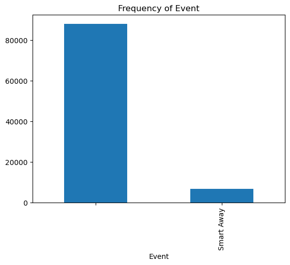

```python
X_train['Event'].value_counts().plot(kind = "bar")
plt.title("Frequency of Event")
plt.show()
```

```python
pd.crosstab(index = X_train['Event'], columns=y_train)
```

| Override Event | No Override | Override |
| --- | --- | --- |
|  | 72117 | 15843 |
| Smart Away | 6648 | 0 |

Smart Away is most likely a thermostat setting engaged when the home owner is away from the house. There are 0 overrides when Smart Away is engaged, which makes sense since no one is home to override the thermostat's setting. "Event" will likely not aid in the performance of a logistic model, but should be considered for decision tree models since the feature can rule out 6648 records in the training set.

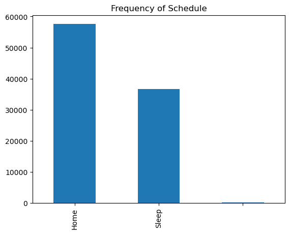

```python
X_train['Schedule'].value_counts().plot(kind = "bar")
plt.title("Frequency of Schedule")
plt.xlabel("")
plt.show()
```

```python
X_train['Schedule'].value_counts()
```

```
Schedule
Home     57561
Sleep    36767
           280
Name: count, dtype: int64
```

```python
pd.crosstab(index = X_train['Schedule'], columns=y_train)
```

| Override Schedule | No Override | Override |
| --- | --- | --- |
|  | 280 | 0 |
| Home | 46354 | 11207 |
| Sleep | 32131 | 4636 |

```python
11207/(11207+46354)
```

```
0.1946977988568649
```

```python
4636/(4636+32131)
```

```
0.1260913319008894
```

```python
57561/(57561+36767)
```

```
0.6102217793232126
```

#### Scatter Plots for Continuous Variables

Using scatter plots to show the distribution of overrides for each of the continuous variables in the training set will give insight to which variables have a strong relationship with the response, indicated by a large numnber of points on one side for the negative case (0, on the bottom) and a high number of points on the opposite side for the positive case (1, on the top).

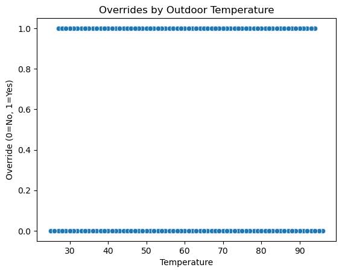

```python
sns.scatterplot(x = X_train["Outdoor_Temperature"], y=y_train_encoded)
plt.title("Overrides by Outdoor Temperature")
plt.xlabel("Temperature")
plt.ylabel("Override (0=No, 1=Yes)")
plt.show()
```

An increase in Outdoor temperature looks to have little effect on whether or not the override is engaged. It may be helpful to bin outdoor temperature into cold, temperate, and hot categories to see if a pattern emerges.

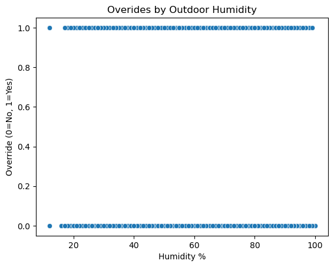

```python
sns.scatterplot(x = X_train["Outdoor_Humidity"], y=y_train_encoded)
plt.title("Overides by Outdoor Humidity")
plt.xlabel("Humidity %")
plt.ylabel("Override (0=No, 1=Yes)")
plt.show()
```

As with outdoor temperature, outdoor humidity has little affect on whether the overide is engaged, with a uniform distribution for both categories.

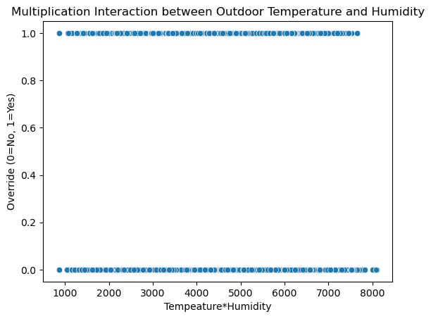

```python
# Interaction with humidty and temperature
sns.scatterplot(x = X_train["Outdoor_Humidity"]*X_train["Outdoor_Temperature"], y=y_train_encoded)
plt.title("Multiplication Interaction between Outdoor Temperature and Humidity")
plt.xlabel("Tempeature*Humidity")
plt.ylabel("Override (0=No, 1=Yes)")
plt.show()
```

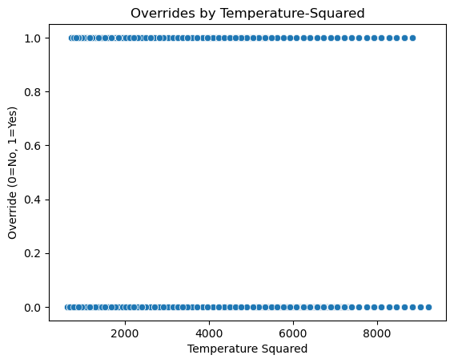

```python
sns.scatterplot(x = X_train["Outdoor_Temperature"]**2, y=y_train_encoded)
plt.title("Overrides by Temperature-Squared")
plt.xlabel("Temperature Squared")
plt.ylabel("Override (0=No, 1=Yes)")
plt.show()
```

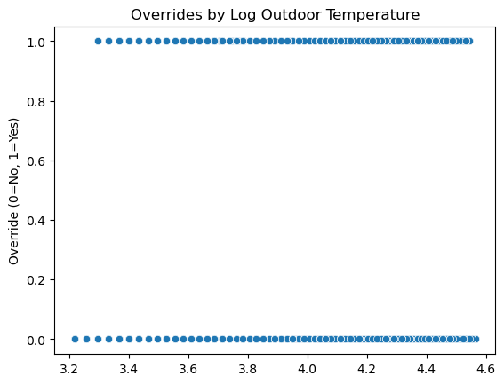

```python
sns.scatterplot(x = np.log(X_train["Outdoor_Temperature"]), y=y_train_encoded)
plt.title("Overrides by Log Outdoor Temperature")
plt.xlabel("")
plt.ylabel("Override (0=No, 1=Yes)")
plt.show()
```

The above scatterplots show that there is little direct relationship between outdoor environnmental factors and the thermostat being overridden.

#### Setpoint Frequencies and Override Crosstabulation

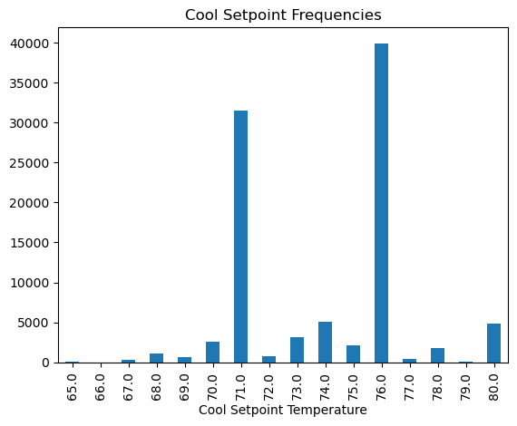

```python
np.floor(X_train["Indoor_CoolSetpoint"]).value_counts().sort_index().plot(kind="bar")
plt.title("Cool Setpoint Frequencies")
plt.xlabel("Cool Setpoint Temperature")
plt.show()
```

```python
pd.crosstab(index = y_train_encoded, columns = np.floor(X_train["Indoor_CoolSetpoint"]))
```

| Indoor_CoolSetpoint row_0 | 65.0 | 66.0 | 67.0 | 68.0 | 69.0 | 70.0 | 71.0 | 72.0 | 73.0 | 74.0 | 75.0 | 76.0 | 77.0 | 78.0 | 79.0 | 80.0 |
| --- | --- | --- | --- | --- | --- | --- | --- | --- | --- | --- | --- | --- | --- | --- | --- | --- |
| 0 | 0 | 0 | 4 | 1 | 5 | 30 | 30010 | 145 | 2081 | 250 | 256 | 39250 | 110 | 1720 | 64 | 4839 |
| 1 | 68 | 21 | 324 | 1102 | 662 | 2597 | 1457 | 663 | 1065 | 4828 | 1923 | 654 | 335 | 116 | 23 | 5 |

Using the frequency distribution of the Indoor_CoolSetpoint, it is likely the smart thermostat is setting the temperature to 71 or 76. Looking at the Cross tabulation of override occurrences at each temperature setting, we see that the temperature is rarely overridden at 71 or 76. At higher set points, the thermostat is rarely overridden (only 5 times in 4844 records where the cool set point was overridden to 80). When the Cool setting is set at a warmer temperature, the homeowner adjusts, or overrides, the thermostat less frequently.

At the other end of the temperature range, most cool set points have been overridden. When the Cool setpoint is at a lower temperature, the homeowner overrides the setting at higher frequency.

Some consideration should be given to the fact that the temperature setpoints may be the *result* of an override. Using randomly split data removes the ability to look at the sequences of data where an override is active and the setpoint changed from one value to another, or that the average temperature changed to represent the new setpoint. But looking at the above crosstabulation, we see the relationship between the cool setpoint and the frequency of overrides, a relationship that was absent when looking at a similar distribution for the continuous outdoor data.

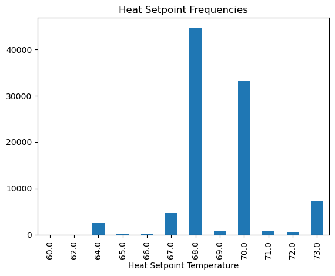

```python
np.floor(X_train["Indoor_HeatSetpoint"]).value_counts().sort_index().plot(kind="bar")
plt.title("Heat Setpoint Frequencies")
plt.xlabel("Heat Setpoint Temperature")
plt.show()
```

```python
pd.crosstab(index = y_train_encoded, columns = np.floor(X_train["Indoor_HeatSetpoint"]))
```

| Indoor_HeatSetpoint row_0 | 60.0 | 62.0 | 64.0 | 65.0 | 66.0 | 67.0 | 68.0 | 69.0 | 70.0 | 71.0 | 72.0 | 73.0 |
| --- | --- | --- | --- | --- | --- | --- | --- | --- | --- | --- | --- | --- |
| 0 | 0 | 0 | 2437 | 43 | 44 | 4340 | 41971 | 324 | 29460 | 62 | 53 | 31 |
| 1 | 22 | 1 | 23 | 24 | 21 | 494 | 2601 | 360 | 3643 | 843 | 574 | 7237 |

A similar pattern emerges for the Heat setpoint: when the thermostat sets a warmer temperature, the homeowner overrides the selection at a much higher frequency.

A feature could be engineered that looked at the absolute difference between the mean (or median) set temperature and the actual set temperature, but consideration would have to be given to time of year and outdoor temperatures to determine if the field would use the Indoor_CoolSetpoint or the Indoor_HeatSetpoint. A value is recorded for each record no matter the time of year, but the Indoor_CoolSetpoint is unlikely to influence a temperature change in winter.

#### Temperature and Humidity Difference

We can use the differnce between the outside temperature and the indoor average temperature (measured over the last five minutes for each record) to see if it is more likely the thermostat will be overridden. For example, if it is much hotter outside than the average indoor temperature, will the user change the set temperature by overriding the thermostat?

```python
hum_diff_data = {
    "Hum_Diff": abs(X_train["Outdoor_Humidity"] - X_train["Indoor_Humidity"]),
    "Override": y_train_encoded
}
hum_diff = pd.DataFrame(hum_diff_data)
```

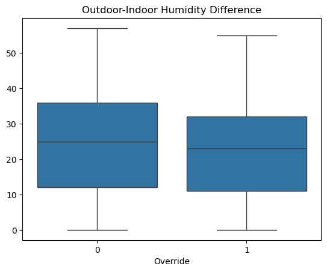

```python
sns.boxplot(x = "Override", y = "Hum_Diff", data = hum_diff)

plt.title("Outdoor-Indoor Humidity Difference")
plt.ylabel("")

plt.show()
```

When the homeowner overrides the thermostat, the median difference between indoor and outdoor humidity is lower compared to when the system is not overridden. This should be expected since the homeowner is likely more comfortable when there is less humidity indoors compared to the warm and humid outdoor environment. (Again, since we don't know the geographic location of the home where the data was collected, this is an assumption.)

```python
temp_diff_data = {
    "Temp_Diff" : abs(X_train["Outdoor_Temperature"] - X_train["Indoor_AverageTemperature"]),
    "Override": y_train_encoded
}

temp_diff = pd.DataFrame(temp_diff_data)
```

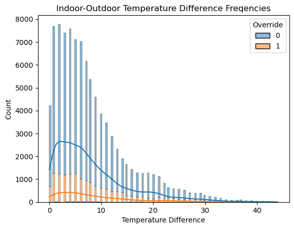

```python
sns.histplot(data = temp_diff, x = "Temp_Diff", hue = "Override", kde=True, multiple = "stack")
plt.title("Indoor-Outdoor Temperature Difference Freqencies")
plt.xlabel("Temperature Difference")
plt.show()
```

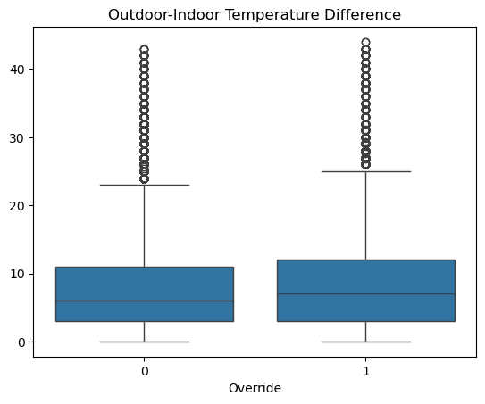

```python
sns.boxplot(x = "Override", y = "Temp_Diff", data = temp_diff)
plt.title("Outdoor-Indoor Temperature Difference")
plt.ylabel("")
plt.show()
```

Looking at the whether the difference in indoor and outdoor humidity and temperature showed that there may some relationship between these differnces and the thermostat being overridden. The differences may not be that significant, but it may be useful to add feature that include a value for these differences.

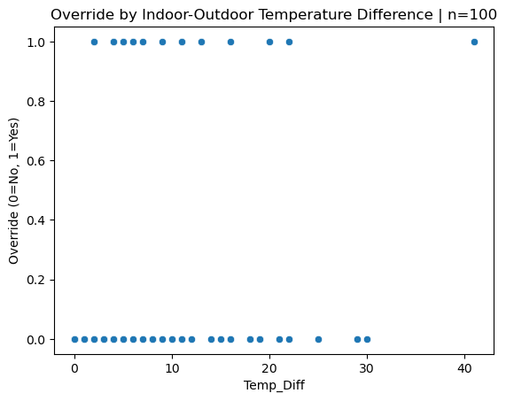

```python
sample = temp_diff.sample(n = 100, random_state = 1)

sns.scatterplot(x = "Temp_Diff", y = "Override", data=sample)
plt.title("Override by Indoor-Outdoor Temperature Difference | n=100")
plt.ylabel("Override (0=No, 1=Yes)")
plt.show()
```

We still are not seeing a clear indication of override, though from the sample, the one record where the indoor-outdoor temperature difference was +40 degrees, we do see the override used on the thermostat.

Again, we may need to reconsider this relationship. When it is very hot outside, a large temperature difference indoors would feel good and would be less likely to cause an override.

#### Hourly Statistics

Is there a higher frequency of overrides based on the hour of the day? If the user comes home from work, will they change the setting? When they get out of bed?

```python
hour_data = {
    "Hour": X_train["date_time"].dt.hour,
    "Override":y_train_encoded
}

hour_df = pd.DataFrame(hour_data)
```

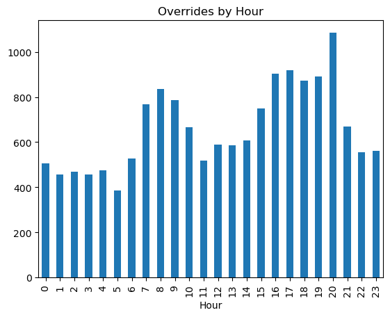

```python
hour_df.groupby("Hour")["Override"].sum().plot(kind = "bar")

plt.title("Overrides by Hour")

plt.show()
```

We do see a higher total override during the afternoon -- from 3 PM to 8 PM. I am surprised by the overrides that occur during the four hours after midnight. This leads me to believe that an "Override" isn't an instance of button push, but for each record (a five minute interval) an override occurs if the set temperature is different than some prescribed setting by the smart thermostat. So if the thermostat is overridden at 8 PM and is kept at that new temperature for an hour, there will be a total of 12 instances of "Override" in the data set. We don't know when the thermostat reverts back to an non-overridden state, even as the average indoor temperature changes because the set temperature has been manually changed.

This will lead to some unreliability when using the indoor measurements, as "Override" is still being recorded despite the environment changing.

#### Will there be more overrides on the weekend?

```python
dow_data = {
    "DOW": X_train["date_time"].dt.weekday,
    "Override":y_train_encoded
}

dow_df = pd.DataFrame(dow_data)
```

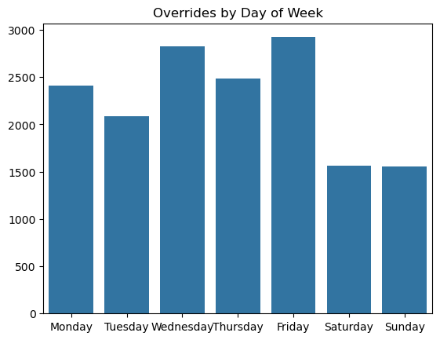

```python
weekday_labels = ['Monday', 'Tuesday', 'Wednesday', 'Thursday', 'Friday', 'Saturday', 'Sunday']
dow_counts =dow_df.groupby("DOW")["Override"].sum()

sns.barplot(x = dow_counts.index, y = dow_counts)
plt.xticks(dow_counts.index, weekday_labels)
plt.title("Overrides by Day of Week")
plt.xlabel("")
plt.ylabel("")
plt.show()
```

The "Override" occurred significantly *fewer times* on weekends compared to weekdays. Fridays had the highest occurence of overrides, followed by Wednesday.

Perhaps the thermostat is programmed for a single temperature on weekends, whereas on weekdays there are multiple settings programmed. If no one is home during the workday, a more energy efficient temperature can be set, but when someone comes home, this setting is manually overridden. On weekends a single, perhaps more comfortable, temperature setting is used for the whole day and is less likely to be changed.

```python
monthly_override_data = {
    "date_time" : X_train["date_time"],
    "override" : y_train_encoded
}

monthly_override = pd.DataFrame(monthly_override_data)
```

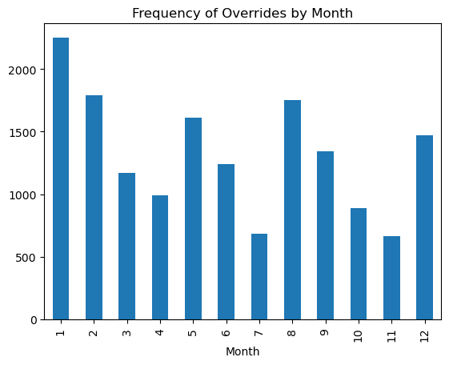

```python
monthly_override.groupby(monthly_override["date_time"].dt.month)["override"].sum().plot(kind = "bar")
plt.title("Frequency of Overrides by Month")
plt.xlabel("Month")
plt.show()
```

The cold winter months see the highest use of the override. Connecting this with the cross tabulation of overrides with set temperatures, the data we are seeing may be an implication of cost-saving by the homeowner who is turning down the heat in the winter and turning up the air conditioning in the summer (August was had the thrid highest rate of override frequencies).

### Feature Engineering

What features do you think will be most important in your model and why? These can be either provided or engineered features. Then, try to be creative in coming up with an expansive set of features to provide to your model. Finally, what features do you think would improve your model that you don't have access to currently and, if you had more time, how would you go about collecting that data?

Features will be added to represent the hour of the day and the day of the week. The EDA of the training data showed that these features show relationships with the override setting. The time features will be additionally engineered to represent the cyclical nature of the predictor field -- sine and cosine.

```python
# Extract time components
X_train['hour'] = X_train['date_time'].dt.hour
X_train['day_of_week'] = X_train['date_time'].dt.dayofweek

# Cyclical encoding
X_train['hour_sin'] = np.sin(2 * np.pi * X_train['hour'] / 24)
X_train['hour_cos'] = np.cos(2 * np.pi * X_train['hour'] / 24)
X_train['day_sin'] = np.sin(2 * np.pi * X_train['day_of_week'] / 7)
X_train['day_cos'] = np.cos(2 * np.pi * X_train['day_of_week'] / 7)
```

Interactions between indoor temperature and humidity and outdoor temperature and humidity will be included. With these features we ask whether the relationship between the temperature and the level of humidity influenced the decision to override the thermostat.

```python
X_train['id_temp_humidity'] = X_train['Indoor_AverageTemperature']*X_train['Indoor_Humidity']
X_train['od_temp_humidity'] = X_train['Outdoor_Temperature']*X_train['Outdoor_Humidity']
```

We can also ask if the absolute difference between the outdoor and indoor temperature has any influence on the likelihood of the override being pressed.

```python
X_train['temp_diff'] = abs(X_train['Indoor_AverageTemperature'] - X_train['Outdoor_Temperature'])
```

Because the "Event" predictor field had no relation to the response -- at no time when an Event was programmed into the thermostat was it overridden -- the field will be dropped.

```python
X_train = X_train.drop("Event", axis=1)
```

```python
X_test.reset_index(inplace = True,
              names = 'date_time')
```

```python
X_test['hour'] = X_test['date_time'].dt.hour
X_test['day_of_week'] = X_test['date_time'].dt.dayofweek

# Cyclical encoding
X_test['hour_sin'] = np.sin(2 * np.pi * X_test['hour'] / 24)
X_test['hour_cos'] = np.cos(2 * np.pi * X_test['hour'] / 24)
X_test['day_sin'] = np.sin(2 * np.pi * X_test['day_of_week'] / 7)
X_test['day_cos'] = np.cos(2 * np.pi * X_test['day_of_week'] / 7)
X_test['id_temp_humidity'] = X_test['Indoor_AverageTemperature']*X_test['Indoor_Humidity']
X_test['od_temp_humidity'] = X_test['Outdoor_Temperature']*X_test['Outdoor_Humidity']
X_test['temp_diff'] = abs(X_test['Indoor_AverageTemperature'] - X_test['Outdoor_Temperature'])
```

### Modeling

#### First Model - Selection and Fitting

Deliberately limit the complexity of your first model using model or feature selection. The goal is to see how much you can get done with a simple model, and not necessarily to create something that performs poorly. Use cross validation if your model has hyperparameters.

```python
# logistic model
from sklearn.linear_model import LogisticRegression

log_model = LogisticRegression(max_iter=10000, random_state = 10)
```

```python
X_features = ['hour','day_of_week','hour_sin', 'hour_cos', 'day_sin', 'day_cos']
```

```python
# logistic regression with limited features
X_model_features = X_train.drop(["date_time","Schedule"], axis=1)


log_model.fit(X_model_features, y_train_encoded)
log_model.predict(X_model_features)
log_model.predict_proba(X_model_features)
```

```
array([[9.99387165e-01, 6.12834794e-04],
       [8.98541753e-01, 1.01458247e-01],
       [9.55218619e-01, 4.47813809e-02],
       ...,
       [9.42609398e-01, 5.73906016e-02],
       [9.98347581e-01, 1.65241881e-03],
       [8.80000787e-01, 1.19999213e-01]])
```

#### First Model - Evaluation

Create an in-sample and out-of-sample ROC curve and calculate the AUC for each.

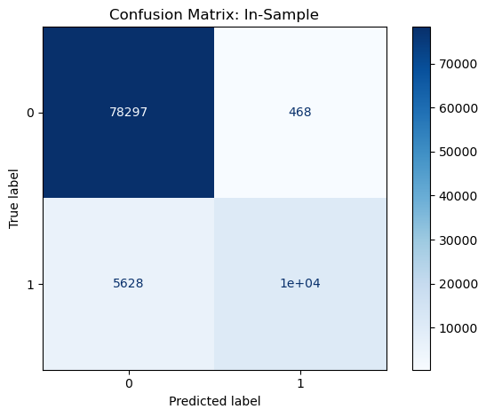

```python
# in-sample confusion matrix

from sklearn.metrics import confusion_matrix, ConfusionMatrixDisplay

cm = confusion_matrix(y_train_encoded, log_model.predict(X_model_features))
disp = ConfusionMatrixDisplay(confusion_matrix=cm,
                              display_labels=log_model.classes_)
disp.plot(cmap='Blues')
plt.title("Confusion Matrix: In-Sample")
plt.tight_layout()

plt.show()
```

```python
cm
```

```
array([[78297,   468],
       [ 5628, 10215]], dtype=int64)
```

```python
from sklearn.metrics import accuracy_score
accuracy = accuracy_score(y_train_encoded, log_model.predict(X_model_features))
print(accuracy)
```

```
0.9355657026889903
```

The accuracy of the model, 0.936, is ten points higher than the naive rate of 0.833.

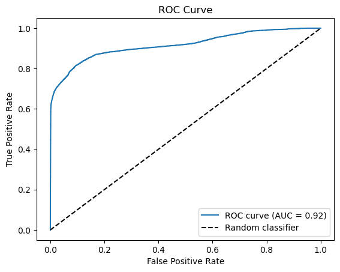

```python
from sklearn.metrics import roc_curve, auc
fpr, tpr, thresholds = roc_curve(y_train_encoded, log_model.predict_proba(X_model_features)[:,1])
roc_auc = auc(fpr, tpr)

plt.figure()
plt.plot(fpr, tpr, label=f'ROC curve (AUC = {roc_auc:.2f})')
plt.plot([0,1], [0,1], 'k--', label = 'Random classifier')
plt.xlabel('False Positive Rate')
plt.ylabel('True Positive Rate')
plt.title('ROC Curve')
plt.legend()
plt.show()
```

With an AUC close to one and a high true positive rate at the onset, this model does well predicting for overrides.

```python
# Get feature names
feature_names = X_model_features.columns

# Get coefficients
coefficients = log_model.coef_[0]  # [0] because it's binary classification

# Create a nice dataframe
coef_df = pd.DataFrame({
    'Feature': feature_names,
    'Coefficient': coefficients
}).sort_values('Coefficient', key=abs, ascending=False)

print(coef_df)
```

```
                      Feature  Coefficient
9                    hour_cos    -3.567115
8                    hour_sin    -1.672348
5         Indoor_HeatSetpoint     1.308029
4         Indoor_CoolSetpoint    -0.991335
1             Indoor_Humidity    -0.427920
0   Indoor_AverageTemperature    -0.344669
11                    day_cos    -0.238390
7                 day_of_week    -0.098702
10                    day_sin    -0.094471
3            Outdoor_Humidity     0.044189
2         Outdoor_Temperature     0.034358
6                        hour    -0.031959
14                  temp_diff     0.011638
12           id_temp_humidity     0.006664
13           od_temp_humidity    -0.000622
```

```python
import statsmodels.api as sm

# Add constant for intercept
X_with_const = sm.add_constant(X_model_features)

# Fit logistic regression
logit_model = sm.Logit(y_train_encoded, X_with_const)
result = logit_model.fit()

# Get summary with coefficients, p-values, confidence intervals
print(result.summary())
```

```
Optimization terminated successfully.
         Current function value: 0.215226
         Iterations 9
                           Logit Regression Results
==============================================================================
Dep. Variable:                      y   No. Observations:                94608
Model:                          Logit   Df Residuals:                    94592
Method:                           MLE   Df Model:                           15
Date:                Sat, 31 Jan 2026   Pseudo R-squ.:                  0.5237
Time:                        20:05:59   Log-Likelihood:                -20362.
converged:                       True   LL-Null:                       -42747.
Covariance Type:            nonrobust   LLR p-value:                     0.000
=============================================================================================
                                coef    std err          z      P>|z|      [0.025      0.975]
---------------------------------------------------------------------------------------------
const                       -23.1230      3.991     -5.793      0.000     -30.946     -15.300
Indoor_AverageTemperature    -0.0861      0.057     -1.515      0.130      -0.197       0.025
Indoor_Humidity              -0.0663      0.073     -0.905      0.366      -0.210       0.077
Outdoor_Temperature           0.0293      0.006      4.515      0.000       0.017       0.042
Outdoor_Humidity              0.0456      0.006      8.212      0.000       0.035       0.056
Indoor_CoolSetpoint          -0.9355      0.012    -77.972      0.000      -0.959      -0.912
Indoor_HeatSetpoint           1.3228      0.013    103.061      0.000       1.298       1.348
hour                         -0.0516      0.003    -18.635      0.000      -0.057      -0.046
day_of_week                  -0.0931      0.012     -7.724      0.000      -0.117      -0.069
hour_sin                     -2.0160      0.043    -46.794      0.000      -2.100      -1.932
hour_cos                     -3.4258      0.044    -77.529      0.000      -3.512      -3.339
day_sin                      -0.0849      0.030     -2.857      0.004      -0.143      -0.027
day_cos                      -0.3261      0.022    -14.499      0.000      -0.370      -0.282
id_temp_humidity              0.0015      0.001      1.489      0.136      -0.000       0.004
od_temp_humidity             -0.0006   8.22e-05     -7.019      0.000      -0.001      -0.000
temp_diff                     0.0127      0.003      4.538      0.000       0.007       0.018
=============================================================================================
```

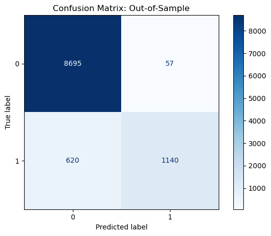

```python
# out of sample evaluation
X_test_features = X_test.drop(["date_time","Schedule", "Event"], axis=1)
cm = confusion_matrix(y_test_encoded, log_model.predict(X_test_features))
disp = ConfusionMatrixDisplay(confusion_matrix=cm,
                              display_labels=log_model.classes_)
disp.plot(cmap='Blues')
plt.title("Confusion Matrix: Out-of-Sample")
plt.tight_layout()
plt.show()
```

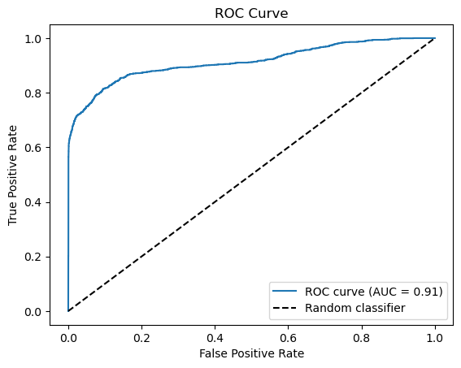

```python
fpr, tpr, thresholds = roc_curve(y_test_encoded, log_model.predict_proba(X_test_features)[:,1])
roc_auc = auc(fpr, tpr)

plt.figure()
plt.plot(fpr, tpr, label=f'ROC curve (AUC = {roc_auc:.2f})')
plt.plot([0,1], [0,1], 'k--', label = 'Random classifier')
plt.xlabel('False Positive Rate')
plt.ylabel('True Positive Rate')
plt.title('ROC Curve')
plt.legend()
plt.show()
```

```python
accuracy = accuracy_score(y_test_encoded, log_model.predict(X_test_features))
print(accuracy)
```

```
0.9355974124809742
```

The logistic model performed similarly on the test set, both in accuracy of predictions and the AUC for the ROC curve.

#### Second Model - Selection and Fitting

A random forest classification ensemble model will be built with the goal of predicting when the thermostat Override is engaged. Cross validation will be used to determine the best set of hyperparameters. Randomized Search Cross Validation is used to reduce computing demands.

```python
# dropping date time and setting up encoded for the schedule
rf_features = X_train.drop("date_time", axis=1)
rf_features = pd.get_dummies(rf_features, columns = ['Schedule'], drop_first = True)
rf_features = rf_features.astype({
    'Schedule_Home': int,
    'Schedule_Sleep': int
})
```

```python
from sklearn.ensemble import RandomForestClassifier
from sklearn.model_selection import RandomizedSearchCV


param_dist_rf = {
    'n_estimators': [100, 200, 300],
    'max_depth': [10, 15, 20, None],
    'min_samples_split': [2, 5, 10],
    'min_samples_leaf': [1, 2, 4],
    'max_features': ['sqrt', 'log2']
}

rf = RandomForestClassifier(random_state=30, n_jobs=-1)
rf_random = RandomizedSearchCV(rf, param_dist_rf,
                               n_iter=100,
                               cv=5,
                               scoring='accuracy',
                               n_jobs=1,
                               verbose=2,
                               random_state=20)

rf_random.fit(rf_features, y_train_encoded)

best_rf = rf_random.best_estimator_
rf_preds = best_rf.predict(rf_features)

rf_accuracy = accuracy_score(y_train_encoded, rf_preds)

print(f"Accuracy: {rf_accuracy: .4f}")
print(f"\nBest Parameters:")
for param, value in rf_random.best_params_.items():
    print(f"  {param}: {value}")
```

```
Fitting 5 folds for each of 100 candidates, totalling 500 fits
[CV] END max_depth=15, max_features=log2, min_samples_leaf=1, min_samples_split=2, n_estimators=100; total time=   7.3s
[CV] END max_depth=15, max_features=log2, min_samples_leaf=1, min_samples_split=2, n_estimators=100; total time=   2.6s
[CV] END max_depth=15, max_features=log2, min_samples_leaf=1, min_samples_split=2, n_estimators=100; total time=   2.7s
[CV] END max_depth=15, max_features=log2, min_samples_leaf=1, min_samples_split=2, n_estimators=100; total time=   2.7s
[CV] END max_depth=15, max_features=log2, min_samples_leaf=1, min_samples_split=2, n_estimators=100; total time=   2.8s
[CV] END max_depth=None, max_features=sqrt, min_samples_leaf=4, min_samples_split=10, n_estimators=200; total time=   5.1s
[CV] END max_depth=None, max_features=sqrt, min_samples_leaf=4, min_samples_split=10, n_estimators=200; total time=   5.1s
[CV] END max_depth=None, max_features=sqrt, min_samples_leaf=4, min_samples_split=10, n_estimators=200; total time=   5.2s
[CV] END max_depth=None, max_features=sqrt, min_samples_leaf=4, min_samples_split=10, n_estimators=200; total time=   5.2s
[CV] END max_depth=None, max_features=sqrt, min_samples_leaf=4, min_samples_split=10, n_estimators=200; total time=   5.3s
[CV] END max_depth=15, max_features=log2, min_samples_leaf=2, min_samples_split=2, n_estimators=300; total time=   7.7s
[CV] END max_depth=15, max_features=log2, min_samples_leaf=2, min_samples_split=2, n_estimators=300; total time=   7.5s
[CV] END max_depth=15, max_features=log2, min_samples_leaf=2, min_samples_split=2, n_estimators=300; total time=   7.6s
[CV] END max_depth=15, max_features=log2, min_samples_leaf=2, min_samples_split=2, n_estimators=300; total time=   7.6s
[CV] END max_depth=15, max_features=log2, min_samples_leaf=2, min_samples_split=2, n_estimators=300; total time=   7.7s
[CV] END max_depth=15, max_features=sqrt, min_samples_leaf=1, min_samples_split=5, n_estimators=300; total time=   7.8s
[CV] END max_depth=15, max_features=sqrt, min_samples_leaf=1, min_samples_split=5, n_estimators=300; total time=   7.6s
[CV] END max_depth=15, max_features=sqrt, min_samples_leaf=1, min_samples_split=5, n_estimators=300; total time=   7.8s
[CV] END max_depth=15, max_features=sqrt, min_samples_leaf=1, min_samples_split=5, n_estimators=300; total time=   7.7s
[CV] END max_depth=15, max_features=sqrt, min_samples_leaf=1, min_samples_split=5, n_estimators=300; total time=   7.5s
[CV] END max_depth=None, max_features=log2, min_samples_leaf=4, min_samples_split=10, n_estimators=300; total time=   7.7s
[CV] END max_depth=None, max_features=log2, min_samples_leaf=4, min_samples_split=10, n_estimators=300; total time=   7.5s
[CV] END max_depth=None, max_features=log2, min_samples_leaf=4, min_samples_split=10, n_estimators=300; total time=   7.6s
[CV] END max_depth=None, max_features=log2, min_samples_leaf=4, min_samples_split=10, n_estimators=300; total time=   7.5s
[CV] END max_depth=None, max_features=log2, min_samples_leaf=4, min_samples_split=10, n_estimators=300; total time=   7.6s
[CV] END max_depth=15, max_features=sqrt, min_samples_leaf=4, min_samples_split=2, n_estimators=200; total time=   5.3s
[CV] END max_depth=15, max_features=sqrt, min_samples_leaf=4, min_samples_split=2, n_estimators=200; total time=   4.9s
[CV] END max_depth=15, max_features=sqrt, min_samples_leaf=4, min_samples_split=2, n_estimators=200; total time=   5.2s
[CV] END max_depth=15, max_features=sqrt, min_samples_leaf=4, min_samples_split=2, n_estimators=200; total time=   5.2s
[CV] END max_depth=15, max_features=sqrt, min_samples_leaf=4, min_samples_split=2, n_estimators=200; total time=   5.0s
[CV] END max_depth=None, max_features=sqrt, min_samples_leaf=1, min_samples_split=2, n_estimators=300; total time=   7.7s
[CV] END max_depth=None, max_features=sqrt, min_samples_leaf=1, min_samples_split=2, n_estimators=300; total time=   7.7s
[CV] END max_depth=None, max_features=sqrt, min_samples_leaf=1, min_samples_split=2, n_estimators=300; total time=   7.6s
[CV] END max_depth=None, max_features=sqrt, min_samples_leaf=1, min_samples_split=2, n_estimators=300; total time=   7.6s
[CV] END max_depth=None, max_features=sqrt, min_samples_leaf=1, min_samples_split=2, n_estimators=300; total time=   7.9s
[CV] END max_depth=10, max_features=sqrt, min_samples_leaf=2, min_samples_split=5, n_estimators=200; total time=   4.7s
[CV] END max_depth=10, max_features=sqrt, min_samples_leaf=2, min_samples_split=5, n_estimators=200; total time=   4.5s
[CV] END max_depth=10, max_features=sqrt, min_samples_leaf=2, min_samples_split=5, n_estimators=200; total time=   4.6s
[CV] END max_depth=10, max_features=sqrt, min_samples_leaf=2, min_samples_split=5, n_estimators=200; total time=   4.7s
```

[output cut: 454 more lines]

```
[CV] END max_depth=15, max_features=log2, min_samples_leaf=1, min_samples_split=5, n_estimators=300; total time=   7.5s
[CV] END max_depth=15, max_features=log2, min_samples_leaf=1, min_samples_split=5, n_estimators=300; total time=   7.6s
[CV] END max_depth=20, max_features=log2, min_samples_leaf=4, min_samples_split=10, n_estimators=200; total time=   5.1s
[CV] END max_depth=20, max_features=log2, min_samples_leaf=4, min_samples_split=10, n_estimators=200; total time=   5.1s
[CV] END max_depth=20, max_features=log2, min_samples_leaf=4, min_samples_split=10, n_estimators=200; total time=   5.1s
[CV] END max_depth=20, max_features=log2, min_samples_leaf=4, min_samples_split=10, n_estimators=200; total time=   5.1s
[CV] END max_depth=20, max_features=log2, min_samples_leaf=4, min_samples_split=10, n_estimators=200; total time=   5.1s
Accuracy:  0.9996

Best Parameters:
  n_estimators: 200
  min_samples_split: 2
  min_samples_leaf: 1
  max_features: sqrt
  max_depth: None
```

**Best Parameters**: n_estimators: 200 min_samples_split: 2 min_samples_leaf: 1 max_features: sqrt max_depth: None

#### Second Model - Evaluation

Create an in-sample and out-of-sample ROC curve and calculate the AUC for each.

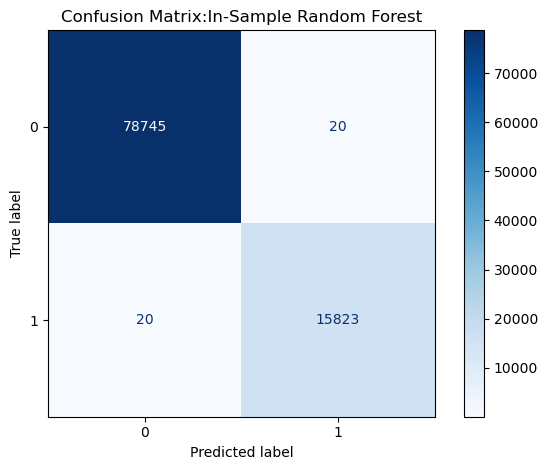

```python
# confusion matrix for in sample

cm = confusion_matrix(y_train_encoded, best_rf.predict(rf_features))
disp = ConfusionMatrixDisplay(confusion_matrix=cm,
                              display_labels=log_model.classes_)
disp.plot(cmap='Blues')
plt.title("Confusion Matrix:In-Sample Random Forest")
plt.tight_layout()
plt.show()
```

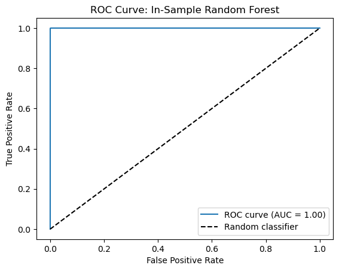

```python
fpr, tpr, thresholds = roc_curve(y_train_encoded, best_rf.predict_proba(rf_features) [:,1])
roc_auc = auc(fpr, tpr)

plt.figure()
plt.plot(fpr, tpr, label=f'ROC curve (AUC = {roc_auc:.2f})')
plt.plot([0,1], [0,1], 'k--', label = 'Random classifier')
plt.xlabel('False Positive Rate')
plt.ylabel('True Positive Rate')
plt.title('ROC Curve: In-Sample Random Forest')
plt.legend()
plt.show()
```

```python
# Adjust features for the test set for the random forest classifier prediction
rf_test = X_test.drop(["date_time", "Event"], axis=1)
rf_test = pd.get_dummies(rf_test, columns = ['Schedule'], drop_first = True)
rf_test = rf_test.astype({
    'Schedule_Home': int,
    'Schedule_Sleep': int
})
```

```python
# use Random forest model to predict the test set

rf_test_preds = best_rf.predict(rf_test)

rf_test_accuracy = accuracy_score(y_test_encoded, rf_test_preds)

print(f"Test set accuracy: {rf_test_accuracy: .4f}")
```

```
Test set accuracy:  0.9958
```

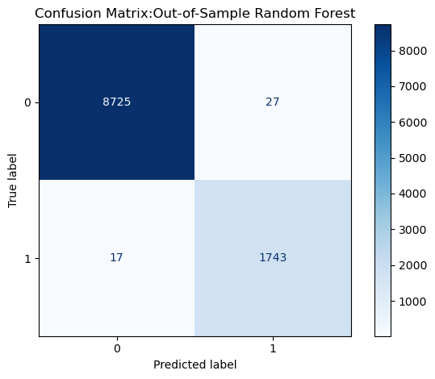

```python
# Confusion matrix for test set

cm = confusion_matrix(y_test_encoded, best_rf.predict(rf_test))
disp = ConfusionMatrixDisplay(confusion_matrix=cm,
                              display_labels=log_model.classes_)
disp.plot(cmap='Blues')
plt.title("Confusion Matrix:Out-of-Sample Random Forest")
plt.tight_layout()
plt.show()
```

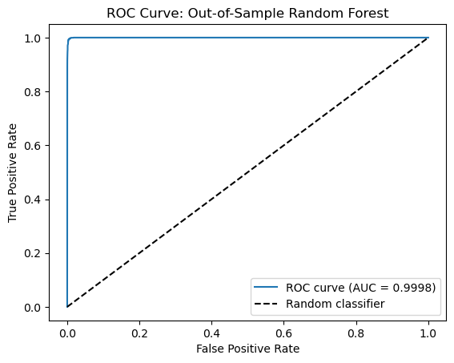

```python
fpr, tpr, thresholds = roc_curve(y_test_encoded, best_rf.predict_proba(rf_test) [:,1])
roc_auc = auc(fpr, tpr)

plt.figure()
plt.plot(fpr, tpr, label=f'ROC curve (AUC = {roc_auc:.4f})')
plt.plot([0,1], [0,1], 'k--', label = 'Random classifier')
plt.xlabel('False Positive Rate')
plt.ylabel('True Positive Rate')
plt.title('ROC Curve: Out-of-Sample Random Forest')
plt.legend()
plt.show()
```

```
                      Feature  Importance
5         Indoor_HeatSetpoint    0.406069
4         Indoor_CoolSetpoint    0.395178
0   Indoor_AverageTemperature    0.027828
2         Outdoor_Temperature    0.019942
13           od_temp_humidity    0.019684
15              Schedule_Home    0.017040
9                    hour_cos    0.014152
12           id_temp_humidity    0.013676
3            Outdoor_Humidity    0.013144
14                  temp_diff    0.012255
16             Schedule_Sleep    0.011940
6                        hour    0.011661
1             Indoor_Humidity    0.010514
8                    hour_sin    0.009938
10                    day_sin    0.006603
7                 day_of_week    0.006315
11                    day_cos    0.004060
```

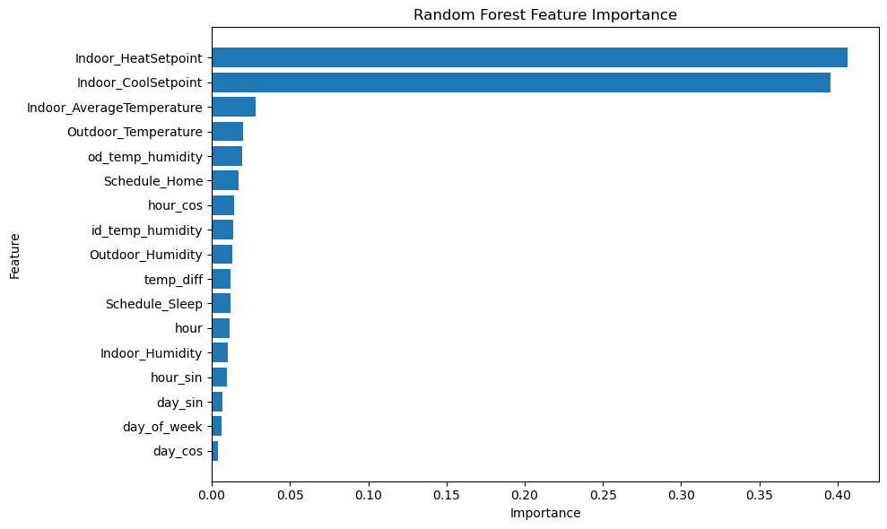

```python
# Get feature importances
feature_importance = pd.DataFrame({
    'Feature': rf_features.columns,
    'Importance': best_rf.feature_importances_
}).sort_values('Importance', ascending=False)

print(feature_importance)

# Visualize
plt.figure(figsize=(10, 6))
plt.barh(feature_importance['Feature'], feature_importance['Importance'])
plt.xlabel('Importance')
plt.ylabel('Feature')
plt.title('Random Forest Feature Importance')
plt.gca().invert_yaxis()  # Highest importance at top
plt.tight_layout()
plt.show()
```

## Conclusion

If our goal is to make the smart thermostat smarter, then the best model to put into production would be the logistic regression model. The logistic regression model produces coefficients that the thermostat can use to make adjustments. For this particular data set, when the thermostat sets itself at a lower temperature during the summer months, the more likely it would be overridden; the higher the temperature setting, the less likely an override by the user. A similar pattern emerged with the heat setting: the higher the heat setting the more likely the occurrence of an override. To put it simply: the customer likes it a little warmer in the summer and a little cooler in the winter. Whether this is a case of personal comfort or minding cost, we cannot say. But the logistic model will allow the agent to be trainable. It can learn that if the temperature setting is at a certain point at a specific time during a particular part of the year it’s okay to tick up the cool setting in the summer and tick down the heat setting during the winter.

Using a logistic model there is less of a penalty for predicting a false positive for the override–we only need enough override signals to teach the thermostat to make adjustments, not to be right every time. The random forest model validates the prediction patterns, and supplies feature importance values that support the logistic model, but it doesn’t give the likelihood of an override.

By creating the two models I learned that, while important, a model that is 100% accurate isn’t always better when it comes to training an AI agent. The random forest model was very accurate and was able to show how it made its decisions, but not why certain features were important, just that they were. The logistic model, while not as accurate, was able to show specific trends in the data that would allow an AI agent to act on its environment.

**Final Analysis**